# Check and recode variables

#### Date: 2024-06-10

### Table 1. StudyID

| Times tested | n_patients |
| --- | --- |
| 1 | 2443 |
| 2 | 508 |
| 3 | 114 |
| 4 | 28 |
| 5 | 11 |
| 6 | 4 |

There are 3108 patients in the original main dataset. There are 2443 patients tested only once, and 665 patients were tested more than once.

### Figure 1. Display age at testing

- Age eligibility:
  - it is possible that they are > 1yo when being tested
  - the mAb is available in October 2023, and is recommended for those under 8 month (CDC), so in theory, only those born after February 2023 are eligible for mAb, these should be included.
  - however, as mAb is also recommended for older high risk infants, also check those born before February and see if they have high risk.
- Generated age_at_testing_in_days, age_at_testing_in_months.

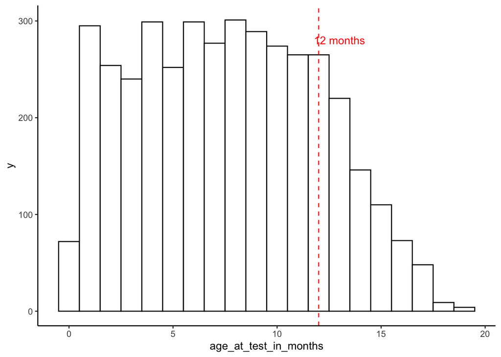

#### There are 724 testing records having age > 12 months at the time of testing. Currently haven’t removed any records. (TBC)

### Table 2. Times tested

| Times tested | n_patients |
| --- | --- |
| 1 | 2443 |
| 2 | 508 |
| 3 | 114 |
| 4 | 28 |
| 5 | 11 |
| 6 | 4 |

StudyID for those who were tested 5 timese: 130577503, 130608912, 130609940, 130635378, 130705659, 130709635, 130745271, 130749578, 130752957, 130755900, 130759159. StudyID for those who were tested 6 timese: 130606175, 130646244, 130654546, 130719972.

### Table 3 Sex

recode unknown to NA.

| Sex | n |
| --- | --- |
| Choose not to disclose | 2 |
| Female | 1712 |
| Male | 2277 |
| Unknown | 1 |

### Figure 2. Sex & Age at testing

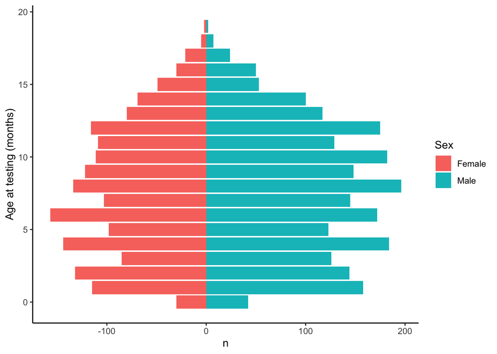

### Figure 3 Collection Date (sample collection date)

Generate collection_date (Date class varaible).

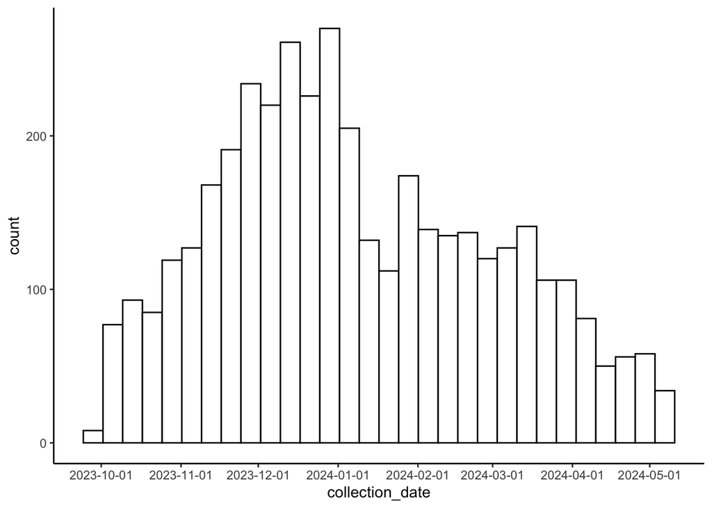

Sample collection date: 2023-09-30 ~ 2024-05-09.

### Viral test, Resp Result, Viral detected:

#### From these variables, generate variables:

- tested_xxx: indicating whether this record was tested for certain virus
- positive_xxx: the testing results for certain virus (flu,rhino,hmpv,adeno,parainfluenza,rsv).
- positive_otherviruses: binary variable indicating that this record was tested positive for other viruses other than RSV (if == 1, this record was tested positive for other viruses, but this record can be either negative and positive for RSV.)

#### From tested_xxx and positive_xxx, generate new variable:

- tested_viruses: string class, listing viruses tested for a record (some viruses are not listed here, like covid)
- positive_viruses: string class, listing viruses tested positive for a record (some viruses are not listed here, like covid)

#### what tests are included in “RESPIRATORY VIRUS PCR PANEL (BH GH LMW Q YH) [LAB3444]”? (TBC, we discussed this, this might not be that important. )

### Table 4. Viral test (taken by a record)

| tested_viruses | n_records |
| --- | --- |
| flu rsv | 3806 |
| flu rhino hmpv adeno parainfluenza rsv | 170 |
| rsv | 16 |

This table shows the number of testing records (w/ duplicates) that took certain tests, some viruses are not included here (like SARS-CoV-2).

### Table 5. Viral test results (by virus combo)

Listing all the combinations of viral test results. Each record contributes one virus combo.

| positive_viruses | n_records |
| --- | --- |
| NO detection of any viruses | 2867 |
| rsv | 850 |
| fluA | 187 |
| fluB | 29 |
| rhino | 23 |
| parainfluenza | 7 |
| hmpv | 6 |
| fluA rsv | 5 |
| adeno | 4 |
| rhino rsv | 3 |

[output cut: 9 more lines]

### Table 6. Viral test results (by single virus)

Listing viruses tested positive, each record can contribute one or more as one record can be tested positive for multiple viruses.

| Virus | n_records | perc |
| --- | --- | --- |
| No.detection | 2867 | 71.8 |
| rsv | 861 | 21.6 |
| fluA | 193 | 4.8 |
| rhino | 32 | 0.8 |
| fluB | 29 | 0.7 |
| adeno | 12 | 0.3 |
| parainfluenza | 11 | 0.3 |
| hmpv | 8 | 0.2 |

### Table 7. Admit Date

#### Generate variable days_btw_admit_collect = collection_date - Admit date. If <0, collection before admission.

| days_btw_admit_collect | n |
| --- | --- |
| -1 | 72 |
| 0 | 3723 |
| 1 | 119 |
| 2 | 2 |
| 3 | 6 |
| 4 | 2 |
| 5 | 5 |
| 6 | 4 |
| 7 | 1 |
| 8 | 4 |

[output cut: 39 more lines]

There are 58 records whose collection date was more than 7 days after admission date. Among, these, there are/is 1 RSV+ case (after the team’s checking (Camila checked this), this single patient, with StudyID of 130615212, the reason for admission was NOT respiratory, the symptoms developed later during admission and that’s why they tested, so this is an unrelated admission), 25 were admitted to ICU on DOB.

### Table 8. Hosp LoS

Length of Stay (in days) of hospitalization originally recorded in the main dataset.

| Hosp LoS | n |
| --- | --- |
| 1 | 3631 |
| 2 | 122 |
| 3 | 54 |
| 4 | 25 |
| 5 | 21 |
| 6 | 14 |
| 7 | 8 |
| 8 | 3 |
| 9 | 6 |
| 10 | 5 |

[output cut: 50 more lines]

#### There are 18 records missing Hosp LoS: (these are all records from BH EMERGENCY DEPARTMENT)

After discussing, these are all outpaitent, thus no hosp stay.

| StudyID | collection_date | Collection Department | tested_viruses | positive_viruses |
| --- | --- | --- | --- | --- |
| 130573578 | 2024-03-13 | BH EMERGENCY DEPARTMENT | flu rsv | NA |
| 130599802 | 2024-03-17 | BH EMERGENCY DEPARTMENT | flu rsv | NA |
| 130613579 | 2023-11-27 | BH EMERGENCY DEPARTMENT | flu rsv | rsv |
| 130626475 | 2024-01-30 | BH EMERGENCY DEPARTMENT | flu rsv | fluA |
| 130635648 | 2024-01-23 | BH EMERGENCY DEPARTMENT | flu rsv | NA |
| 130637034 | 2023-12-18 | BH EMERGENCY DEPARTMENT | flu rsv | NA |
| 130667931 | 2023-12-14 | BH EMERGENCY DEPARTMENT | flu rsv | NA |
| 130673688 | 2023-12-26 | BH EMERGENCY DEPARTMENT | flu rsv | rsv |
| 130678248 | 2023-10-24 | BH EMERGENCY DEPARTMENT | flu rsv | NA |
| 130705752 | 2024-02-15 | BH EMERGENCY DEPARTMENT | flu rsv | rsv |

[output cut: 8 more lines]

#### Generate new variable hosp_los:

- if the encounter type is outpatient —> NA, as there should not be hosp stay for outpatient.

| hosp_los | n |
| --- | --- |
| 1 | 425 |
| 2 | 122 |
| 3 | 54 |
| 4 | 25 |
| 5 | 21 |
| 6 | 14 |
| 7 | 8 |
| 8 | 3 |
| 9 | 6 |
| 10 | 5 |

[output cut: 50 more lines]

### Table 9. Collection Department & Admission location

#### Recode these two to sample_source variable (might not use this variable?):

- if Admission Location is available, use Admission Location;
- if Admission Location is not available, use Collection Department.

| sample_source | n |
| --- | --- |
| YNH 20 YORK ST | 1508 |
| BH 267 GRANT ST | 1083 |
| GH 5 PERRYRIDGE RD | 452 |
| LMH 365 MONTAUK AVE | 286 |
| YNH MAIN LAB | 156 |
| LMH 52 HAZELNUT HILL RD | 98 |
| BH 309 STILLSON RD | 87 |
| WH DRAW STATION MORGAN BLDG | 52 |
| WH 25 WELLS ST | 37 |
| GH LABORATORY SPECIMENS | 34 |

[output cut: 20 more lines]

### Table 10. Original Encounter type

This is the Encounter Type recorded in the original main dataset.

| Encounter Type | n |
| --- | --- |
| Emergency | 2763 |
| Inpatient | 476 |
| Specimen | 415 |
| Observation | 212 |
| Outpatient | 45 |
| NA | 41 |
| Newborn | 39 |
| Hospital Outpatient Surgery | 1 |

### Table 11. Records missing Encounter type

There are records missings for original “encounter type” variable. Most from LABs or DRAW STATION except one record from “NE PEDS OLD SAYBROOK” (after discussing, this one is an outpatient record). Fill in these missings with “Specimen” or “Outpatient”.

| StudyID | Collection Department | Admission Location | Encounter Type |
| --- | --- | --- | --- |
| 130577299 | BH FAM MED DRAW STATION QUARRY ROAD | BH 112 QUARRY RD | NA |
| 130618380 | YNH MAIN LAB | FHC 150 SARGENT DR | NA |
| 130637897 | YNH MAIN LAB | FHC 150 SARGENT DR | NA |
| 130664143 | YNH MAIN LAB | FHC 150 SARGENT DR | NA |
| 130690479 | YNH MAIN LAB | FHC 150 SARGENT DR | NA |
| 130741285 | YNH MAIN LAB | FHC 150 SARGENT DR | NA |
| 130718972 | YNH DRAW STATION E H MAIN ST | FHC 374 GRAND AVE | NA |
| 130688726 | BH FAM MED DRAW STATION QUARRY ROAD | NE 112 QUARRY ROAD | NA |
| 130576042 | YNH MAIN LAB | NE 2200 WHITNEY AVE | NA |
| 130583809 | YNH MAIN LAB | NE 2200 WHITNEY AVE | NA |

[output cut: 31 more lines]

### Table 12. Aggregate “Encounter Type” to fewer categories

#### Generated new variable: encounter_type, coded as:

- Emergency —> outpatient
- Outpatient —> outpatient
- Hospital Outpatient Surgery —> outpatient
- Specimen —> outpatient
- Inpatient —> inpatient
- Observation —> inpatient
- Newborn —> inpatient
- if days_btw_admit_collect > 7 days, change from “inpatient” to “inpatient_unrelated”.

| encounter_type | n_records |
| --- | --- |
| inpatient | 669 |
| inpatient_unrelated | 58 |
| outpatient | 3265 |

### Table 13. ICU admission date

#### Generated new variables:

- date_icu_admit: the same as ICU Admission Date but in Date class, N/A as NA;
- days_btw_collection_icu: days between sample collection and ICU admission (collection_date - ICU admission)
- icu_admitted: categorical variable indicating whether the icu can be related to the testing result (within a week of testing, TBC), taking values of:
  - yes
  - yes_unrelated: days_btw_collection_icu > 7
  - no

| days_btw_collection_icu | n |
| --- | --- |
| -7 | 1 |
| -4 | 1 |
| -3 | 2 |
| -2 | 1 |
| -1 | 17 |
| 0 | 69 |
| 1 | 4 |
| 2 | 3 |
| 3 | 5 |
| 4 | 2 |

[output cut: 41 more lines]

#### Out of 168 ICU admissions, 55 have ICU admission more than 7 days before or after sample collection date. Check these: (1 RSV+, 9 took mAb)

| StudyID | DOB | admit_date | date_icu_admit | collection_date | days_btw_collection_icu | positive_rsv | type |
| --- | --- | --- | --- | --- | --- | --- | --- |
| 130609940 | 2023-01-17 | 2023-01-17 | 2023-01-17 | 2023-10-15 | 271 | 0 | ICU admission on DOB |
| 130609940 | 2023-01-17 | 2023-01-17 | 2023-01-17 | 2023-10-22 | 278 | 0 | ICU admission on DOB |
| 130609940 | 2023-01-17 | 2023-01-17 | 2023-01-17 | 2023-10-27 | 283 | 0 | ICU admission on DOB |
| 130615212 | 2023-01-28 | 2023-12-06 | 2023-12-07 | 2024-01-02 | 26 | 1 | NA |
| 130654546 | 2023-05-09 | 2023-10-05 | 2023-10-05 | 2023-10-29 | 24 | 0 | NA |
| 130662384 | 2023-05-31 | 2023-05-31 | 2023-05-31 | 2023-11-02 | 155 | 0 | ICU admission on DOB |
| 130762941 | 2023-06-20 | 2024-01-05 | 2024-01-05 | 2024-01-13 | 8 | 0 | NA |
| 130678460 | 2023-06-29 | 2023-10-06 | 2023-10-06 | 2023-10-20 | 14 | 0 | NA |
| 130678460 | 2023-06-29 | 2023-10-06 | 2023-10-06 | 2023-11-13 | 38 | 0 | NA |
| 130685383 | 2023-07-15 | 2023-07-15 | 2023-07-15 | 2023-12-05 | 143 | 0 | ICU admission on DOB |

[output cut: 45 more lines]

### Figure 4. ICU admission date

These are ICU admissions within 7 days of sample collection date.

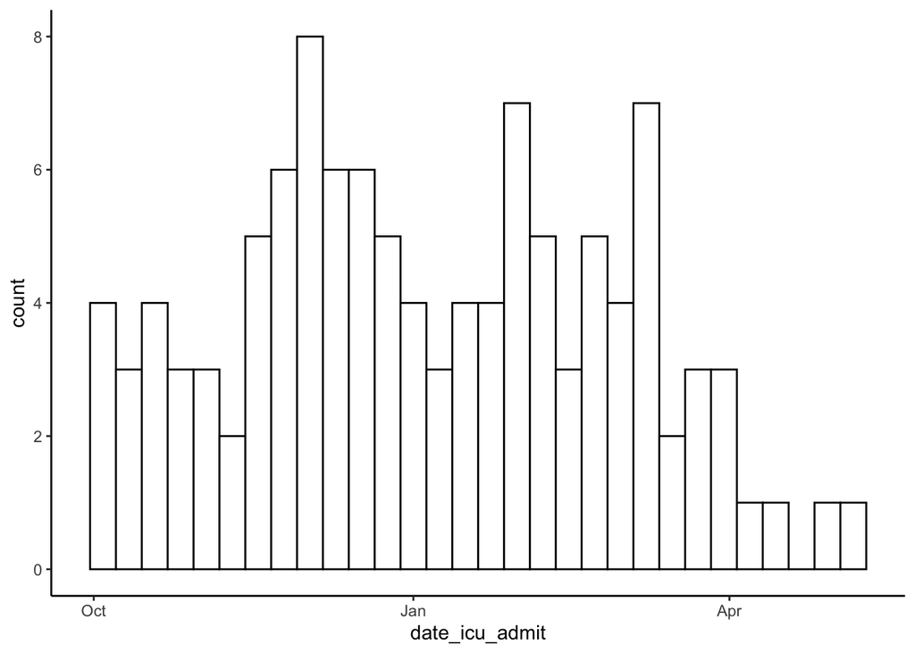

### Figure 5. ICU LOS

#### The original data was in XXd XXh format. Generate new variables:

- icu_los_hours (unit: hour)
- icu_los_days (unit: day)

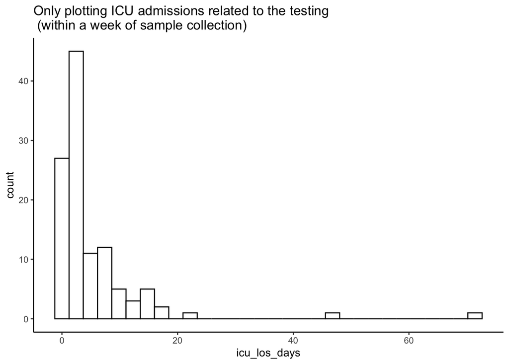

Several infants with ICU LOS longer than 1 month:

### Table 14.

| StudyID | Collection Date | date_icu_admit | icu_los_days |
| --- | --- | --- | --- |
| 130746598 | 2023-12-04T00:00:00Z | 2023-12-04 | 46.875 |
| 130767993 | 2024-01-24T00:00:00Z | 2024-01-18 | 71.875 |

### Figure 6. Gest age (as recorded in “Gest Age” variable)

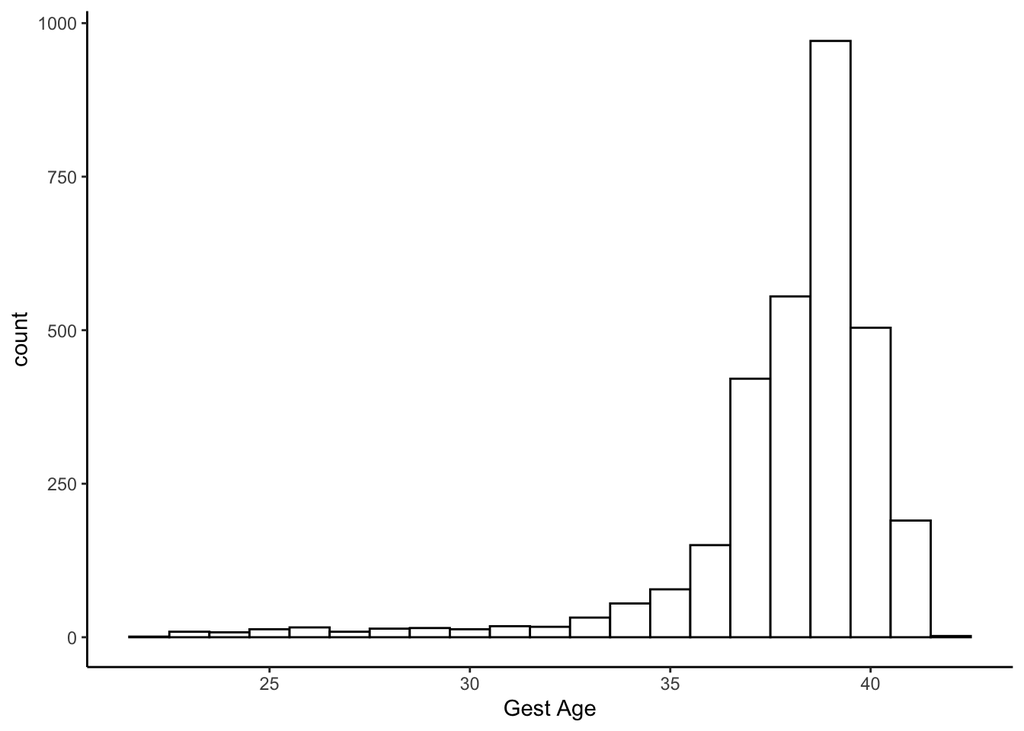

#### Generate categorical variable of gest age: gest_age_cat **(is the following classification okay? combine groups?)**

#### Reference: https://www.cdc.gov/nchs/data/nvsr/nvsr73/nvsr73-01.pdf

- 42 and +: post term
- 41: late term
- 39-40: full term
- 37-38: early term
- < 37: preterm

### Table 15. Gest Age (classified only using “Gest Age” variable)

#### In addition to “Gest Age” variable, I will also use Medical History, Problems.. variables to classify gestational age to fill in NA here, see below.

| gest_age_cat | n_records | perc |
| --- | --- | --- |
| full term | 1475 | 36.9 |
| early term | 976 | 24.4 |
| NA | 901 | 22.6 |
| preterm | 448 | 11.2 |
| late term | 190 | 4.8 |
| post term | 2 | 0.1 |

### Figure 7. Birth weight

- PENDING: Generate birth_weight_kg (numeric), low_birth_weight (binary). Low birth weight is defined as a birth weight of less than 2500 g (up to and including 2499 g), as per the World Health Organization (WHO).
- what is the unit of original variable Birth Wgt (ounce??)? Haven’t generated new variables (TBC?).
- After confirming, generate risk factor indicating low birth weight.

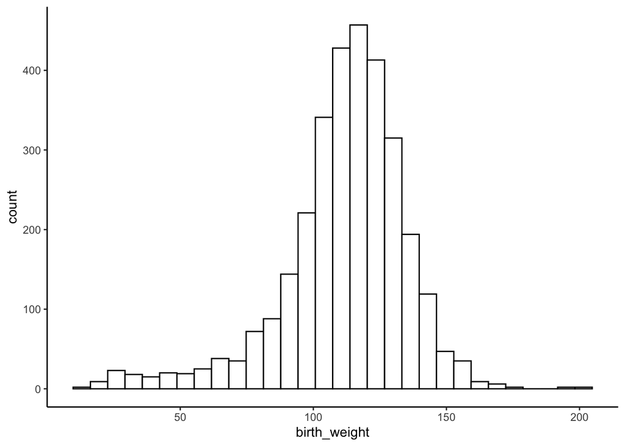

### Table 16. Race and Ethnicity

There are many conflicting answers. Here are the unique answers for Race variable:

| Race | n |
| --- | --- |
| White | 1547 |
| I Do Not See My Race Listed Here | 941 |
| Black or African American | 753 |
| I Do Not Know | 272 |
| Asian | 97 |
| I Prefer Not To Share | 78 |
| Black or African American White | 47 |
| I Do Not See My Race Listed Here White | 33 |
| White Black or African American | 28 |
| NA | 21 |

[output cut: 39 more lines]

#### To classify race, generate new variable “race”. I use dominant answers to classify, e.g. if a records answered both black and white, use black.

```r
df <- df %>%
  mutate(race = case_when(str_detect(Race, "Black") ~ "Black",
                          Race %in% c("White",
                                      "I Do Not See My Race Listed Here\r\nWhite",
                                      "White\r\nI Do Not Know",
                                      "White\r\nI Do Not See My Race Listed Here",
                                      "I Do Not Know\r\nWhite",
                                      "I Prefer Not To Share\r\nWhite",
                                      "White\r\nI Do Not Know\r\nI Do Not See My Race Listed Here") ~ "White",
                          Race %in% c("Asian",
                                      "Asian\r\nWhite",
                                      "White\r\nAsian",
                                      "Asian\r\nI Do Not Know",
                                      "Asian Indian",
                                      "Asian\r\nPacific Islander\r\nWhite",
                                      "Asian\r\nI Do Not Know\r\nWhite") ~ "Asian",
                          Race %in% c("Pacific Islander\r\nWhite",
                                      "White\r\nPacific Islander",
                                      "Pacific Islander\r\nI Do Not See My Race Listed Here",
                                      "American Indian or Native American",
                                      "Middle Eastern or Northern African",
                                      "Pacific Islander",
                                      "American Indian or Native American\r\nI Do Not Know",
                                      "Other\r\nI Do Not See My Race Listed Here",
                                      "I Do Not See My Race Listed Here",
                                      "I Do Not See My Race Listed Here\r\nI Do Not Know",
                                      "I Do Not Know\r\nI Do Not See My Race Listed Here",
                                      "I Do Not See My Race Listed Here\r\nI Prefer Not To Share",
                                      "White\r\nAmerican Indian or Native American",
                                      "Other") ~ "Other",
                          Race %in% c("I Do Not Know",
                                      "I Prefer Not To Share") ~ "unknown")) %>%
  # combine Asian to "Other" category
  mutate(race = ifelse(race == "Asian", "Other", race)) %>%
  mutate(race = ifelse(is.na(race), "unknown", race))

df %>% count(race) %>%
  mutate(perc = round(n/nrow(df) * 100,1)) %>%
  reactable(style = list(color = "black", `font-family` = "Georgia", `font-size` = "15px"))
```

| race | n | perc |
| --- | --- | --- |
| Black | 874 | 21.9 |
| Other | 1125 | 28.2 |
| White | 1616 | 40.5 |
| unknown | 377 | 9.4 |

| Ethnicity | n |
| --- | --- |
| Not Hispanic or Latino/a/e | 2050 |
| Hispanic or Latino/a/e | 1665 |
| I Do Not Know | 182 |
| I Prefer Not To Share | 41 |
| Puerto Rican | 21 |
| NA | 20 |
| Mexican, Mexican American, Chicano/a | 13 |

#### Combine race and ethnicity into one variable: generate this new variable called “race_ethnicity”

#### Method 1 to combine race and ethnicity:

- Hispanic & not black & not white —> hispanic
- Hispanic & other/unknown race —> hispanic
- Black (any ethnicity) —> Black
- white (any ethnicity) —> white
- other race & not Hispanic/unknown ethnicity —> other
- other race & not Hispanic/unknown ethnicity —> unknown

```r
df <- df %>%
  mutate(ethnicity = case_when(Ethnicity %in% c("Not Hispanic or Latino/a/e") ~ "Not Hispanic or Latino",
                               Ethnicity %in% c("Hispanic or Latino/a/e",
                                                 "Puerto Rican",
                                                 "Mexican, Mexican American, Chicano/a") ~ "Hispanic or Latino",
                               Ethnicity %in% c("I Prefer Not To Share",
                                                "I Do Not Know") ~ "unknown"))


# combine race and ethnicity (Method 1)
df <- df %>%
  mutate(race_ethnicity = case_when(race == "Black" ~ "Black",
                                    race == "White" ~ "White",
                                    race %in% c("Other", "unknown") & ethnicity %in% c("Hispanic or Latino") ~ "Hispanic or Latino",
                                    race == "Other" & ethnicity %in% c("Not Hispanic or Latino", "unknown") ~ "Other",
                                    race == "unknown" & ethnicity %in% c("Not Hispanic or Latino", "unknown") ~ "unknown",
                                    TRUE ~ "unknown"))

df %>% count(race_ethnicity) %>% arrange(desc(n)) %>% mutate(perc = round(n/nrow(df)*100,1)) %>%
  reactable(style = list(color = "black", `font-family` = "Georgia", `font-size` = "15px"))
```

| race_ethnicity | n | perc |
| --- | --- | --- |
| White | 1616 | 40.5 |
| Hispanic or Latino | 1027 | 25.7 |
| Black | 874 | 21.9 |
| Other | 240 | 6 |
| unknown | 235 | 5.9 |

#### Method 2 to combine race and ethnicity:

```r
df <- df %>%
  mutate(race_ethnicity_2 = case_when(ethnicity == "Hispanic or Latino" ~ "Hispanic or Latino",
                                      race == "Black" & ethnicity == "Not Hispanic or Latino" ~ "Black non-Hispanic",
                                      race == "Other" & ethnicity == "Not Hispanic or Latino" ~ "Other non-Hispanic",
                                      race == "White" & ethnicity == "Not Hispanic or Latino" ~ "White non-Hispanic",
                                      TRUE ~ "unknown"))
df %>% count(race_ethnicity_2) %>% arrange(desc(n)) %>% mutate(perc = round(n/nrow(df)*100,1)) %>%
  reactable(style = list(color = "black", `font-family` = "Georgia", `font-size` = "15px"))
```

| race_ethnicity_2 | n | perc |
| --- | --- | --- |
| Hispanic or Latino | 1699 | 42.6 |
| White non-Hispanic | 1082 | 27.1 |
| Black non-Hispanic | 687 | 17.2 |
| unknown | 289 | 7.2 |
| Other non-Hispanic | 235 | 5.9 |

### Table 17. Primary Insurance & Payor

#### Generate new variable insurance_type (TBC)

- Medicare / Medicaid —> public insurance
- Most others —> private insurance
- Who are considered as “uninsured”? (patients having NA for Primary Insurance and Payor variable? n = 17)
- After discussing, made some changes to classification. I googled the Insurance and reclassified some. Aim to use this variable to see the SES background of patients.

| insurance_type | n_records |
| --- | --- |
| public | 2661 |
| private | 1305 |
| uninsured | 26 |

### Table 18. Fever?

This variable displays whether the patient had a fever according to the NHSN definition (>38 C) within three days of the collection date. The information appears as a Yes or a No.

| Fever? | n |
| --- | --- |
| No | 2699 |
| Yes | 1293 |

### Table 19. Temp

The most recent flowsheet data for temperature. Convert to new numeric variable recent_temp. (Might not be useful as this is the “most recent” temperature, but I used this below in generating symptom variables, if recent_temp>38, I considered this record had fever symptom.)

| recent_temp | n |
| --- | --- |
| 40.4 | 4 |
| 40.1 | 4 |
| 39.7 | 1 |
| 39.6 | 3 |
| 39.5 | 1 |
| 39.4 | 3 |
| 39.3 | 10 |
| 39.2 | 7 |
| 39.1 | 8 |
| 39 | 8 |

[output cut: 35 more lines]

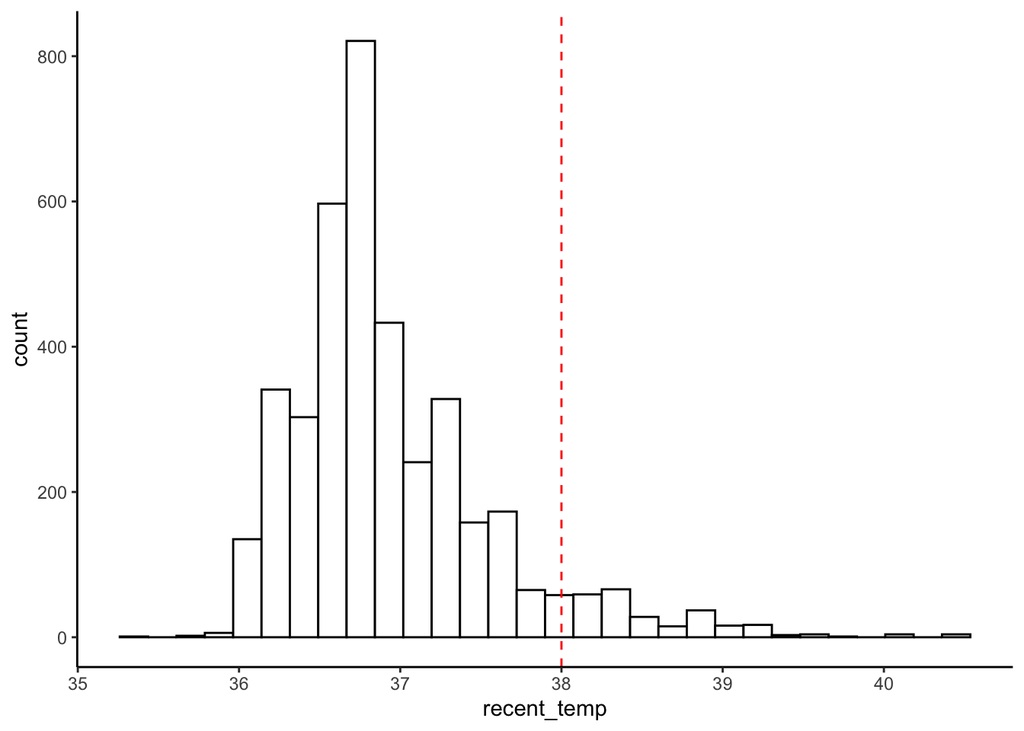

### Last PCP visit (haven’t processed)

### Last Well Child visit (haven’t processed)

### Recent contact (haven’t processed)

### Below are text patterns to detect risk factors (i.e. underlying conditions) and respiratory symptoms from the following variables:

- Medical History (past) —> risk factors
- Problem List (past + current, more from past based on descriptions) —> risk factors
- Primary Problem (current) —> risk factors & respiratory symptoms
- ED Dx (current) —> risk factors & respiratory symptoms
- Admit Dx (current) —> risk factors & respiratory symptoms
- Hospital Problem List (current + past, more from current) —> risk factors & respiratory symptoms

#### I detected the presence of these patterns to see if a record has certain risk factor (based on past and current encounters) or show a certain respiratory symptom in current encounter (based on diagnosis records of current encounter). The new variables generated are binary variables. For example, med_hist_congen_heart means that based on description in the “Medical History” variable, this records had congenital heart disease, which can be a risk factor for more severe outcomes.

```r
######################################
# patterns for underlying risk factors
######################################

pattern_anemia <- paste(c("anemia",
                          "S-C",
                          "thalassemia",
                          "Hemoglobin S-S disease",
                          "Sickle cell",
                          "sickle-cell",
                          "Hemoglobin S trait"),
                        collapse = "|")

pattern_blood <- paste(pattern_anemia,
                       c("hemangioma",
                         "Thrombus of aorta",
                         "hypoglycemia"),
                       collapse = "|")

pattern_asthma <- paste(c("asthma",
                          "Reactive airway disease"),
                        collapse = "|")


pattern_liver <- paste(c("liver cell damage",
                         "Liver cell injury",
                         "liver disease",
                         "Decompensated hepatic cirrhosis",
                         "Liver transplanted"),
                       collapse = "|")

pattern_immunodeficiency <- paste(c("liver transplanted",
                                    "transplant",
                                    "leukemia"),
                                  collapse = "|")

pattern_cvd <- paste(c("Atrial septa",
                       "ventricular septa",
                 "Patent ductus arteriosus",
                 "Cardiac abnormality",
                 "Cardiac hypertrophy", # added
                 "cardiac septal defect", # added
                 "fetal cardiac arrhythmia", # added
                 "Cardiac dysfunction", # added
                 "cardiac arrest", # added
                 "Stenosis of right pulmonary artery", # added
                 "Stenosis of left pulmonary artery", # added
                 "Stenosis of pulmonary artery", # added
                 "Cardiac abnormality", # added
                 "cardiac surgery", # added
                 "cardiac valve disease", # added
                 "Cardiac anomaly", # added
                 "Congenital heart disease",
                 "Partial AV canal",
                 "Ventricular septa",
                 "Coarctation of aorta",
                 "double outlet right ventricle",
                 "Dextrocardia",
                 "DORV",
                 # "Heart murmur",
                 # "Heart murmur of newborn",
                 # "murmur",
                 "heart problem",
                 "Mitral regurgitation",
                 "Kawasaki disease",
                 "Coarctation of aorta",
                 # "hemangioma", # moved to blood group
                 "atrial septal defect",
                 # "Thrombus of aorta", # moved to blood group
                 "premature atrial contraction",
                 "Cardiomegaly",
                 "Myocarditis",
                 "supraventricular tachycardia",
                 "Tetralogy of Fallot",
                 "Atrioventricular canal (AVC), complete",
                 "Heart failure",
                 "Aortic arch anomaly",
                 "supraventricular tachycardia",
                 "aortic coarctation",
                 "Enlarged heart"),
                 collapse = "|")


# pattern_leukemia <- "leukemia" # combined with immunodeficiency group


pattern_gi <- paste(c(
                      # "Abdominal distension",
                      # "Acid reflux",
                      # "gastroesophageal reflux",
                      "GI disease",
                      # "Constipation",
                      "Esophageal atresia",
                      "Gastric perforation",
                      # "Gastric reflux",
                      "Hirschsprung",
                      # "GERD",
                      "Colostomy",
                      "necrotizing enterocolitis",
                      "Intestinal perforation",
                      "Intussusception",
                      "Biliary atresia",
                      "Ileostomy",
                      # "esophageal reflux",
                      "Pyloric stenosis",
                      # "Reflux gastritis",
                      "Gastric bleed",
                      "GI bleed",
                      "gastritis"),
                    collapse = "|")


pattern_congen_heart <- paste(c("Congenital heart disease",
                                "Coarctation of aorta",
                                "Congenital heart",
                                "D-TGA",
                                "double outlet right ventricle",
                                "Dextrocardia",
                                "DORV",
                                "Cardiac abnormality",
                                "ventricular septa",
                                "Mitral regurgitation",
                                "Coarctation of aorta",
                                "Hypoplastic aortic arch",
                                "atrial septal defect",
                                # "Thrombus of aorta", # moved to blood group
                                "Heart abnormality",
                                "Cardiomegaly",
                                "patent ductus arteriosus",
                                "Tetralogy of Fallot",
                                "Atrioventricular canal (AVC), complete",
                                "persistent left superior vena cava",
                                "Aortic arch anomaly",
                                "Wolff-Parkinson-White (WPW) syndrome",
                                "supraventricular tachycardia",
                                "Partial AV canal",
                                "Atrial septa",
                                # "Heart murmur of newborn",
                                "supraventricular tachycardia",
                                "Partial anomalous pulmonary venous return",
                                "aortic coarctation",
                                "Congenital coronary artery fistula to pulmonary artery",
                                "Peripheral pulmonic stenosis",
                                "Tricuspid atresia with normal great arteries"),
                              collapse = "|")
```

```r
pattern_cardiac <- paste(pattern_cvd,
                         pattern_congen_heart,
                         c("Pulmonary valve atresia",
                           "Partial anomalous pulmonary venous return",
                           "pulmonary artery stenosis",
                           "pulmonary artery",
                           "Peripheral pulmonic stenosis",
                           "Pulmonary valve stenosis",
                           "Pulmonary hypertension"),
                         collapse = "|")


pattern_pulmonary <- paste(c(
                             # "Pulmonary valve atresia", # moved to cardiac
                             # "Chronic cough",
                             "CPAM",
                             "Cystic fibrosis",
                             "Bronchopulmonary dysplasia",
                             "Protracted bacterial bronchitis",
                             "reactive airway disease",
                             "Pneumothorax",
                             #"Pulmonary hypertension",
                             #"Pulmonary valve stenosis",
                             "Bronchomalacia",
                             "Tracheomalacia"
                             # "Partial anomalous pulmonary venous return",
                             # "pulmonary artery stenosis",
                             # "pulmonary artery",
                             # "Peripheral pulmonic stenosis"
                             ),
                           collapse = "|")

pattern_down <- paste(c("Down syndrome",
                        "Trisomy 21"),
                      collapse = "|")

# 37-38 weeks
pattern_earlyterm <- paste(c("37 completed weeks",
                             "38 completed weeks",
                             "37 weeks gestation",
                             "38 weeks gestation"),
                           collapse = "|")

# 39-40 weeks
pattern_fullterm <- paste(c("39 completed weeks",
                            "39 weeks gestation",
                            "Term newborn",
                            "Term birth",
                            "40 completed weeks",
                            "40 weeks gestation"),
                          collapse = "|")

# < 37 weeks
pattern_preterm <- paste(c("Premature",
                           "prematurity",
                           "Extremely low birth weight",
                           "Preterm",
                           "36 weeks gestation",
                           "36 completed weeks",
                           "preterm newborn",
                           "preterm birth",
                           "33-34 completed weeks",
                           "29-30 completed weeks",
                           "35-36 completed weeks",
                           "34 completed weeks",
                           "35 completed weeks",
                           "22 weeks gestation"),
                         collapse = "|")

# >= 42 weeks
pattern_postterm <- paste(c("post-term",
                            "post term"),
                          collapse = "|")



######################################
# patterns for respiratory symptoms
######################################

# for upper respiratory tract diseases
pattern_URTI <- paste(c("Abnormal breathing",
                        "Breathing difficulty",
                        "difficulty breathing",
                        "breathing problem",
                        "Shortness of breath",
                        "cough",
                        "Acute obstructive laryngitis",
                        "pharyngitis",
                        "otitis media",
                        "upper respiratory infection",
                        "upper respiratory tract infection",
                        "upper resp. tract infection",
                        "upper resp. infection",
                        "croup",
                        "Nasopharyngitis",
                        "Pain in throat",
                        "reactive airway disease",
                        "Nasal congestion",
                        # "wheezing", # moved to LRT
                        "sore throat",
                        "URI",
                        "Laryngeal stridor"),
                      collapse = "|")

# for lower respiratory tract diseases:
pattern_LRTI <- paste(c("bronchiolitis",
                        "Laryngotracheobronchitis",
                        "Bronchospasm",
                        "Acute chest syndrome",
                        "Acute hypoxic respiratory failure",
                        "Pneumonia",
                        "Hypoxia",
                        "Hypoxemia",
                        "Lower resp. tract infection",
                        "Lower resp. infection",
                        "Lower respiratory tract infection",
                        "Lower respiratory infection",
                        "Hypoxemic respiratory failure",
                        "Acute respiratory failure with hypoxia",
                        "wheezing"),
                      collapse = "|")


pattern_fever <- "fever|febrile"

pattern_cough <- "cough"

pattern_wheezing <- "wheezing"

pattern_breathing <- paste(c("Abnormal breathing",
                             "Breathing difficulty",
                             "difficulty breathing",
                             "Shortness of breath",
                             "breathing problem",
                             "apnea"),
                           collapse = "|")

pattern_bronchiolitis <- "bronchiolitis|Bronchospasm"

pattern_sepsis <- "sepsis"

# pattern_apnea <- "apnea"

# some general terms used to detect if the record's encounter is suspcted resp infection
pattern_suspect_resp_general <- paste(c("respiratory",
                                        "RSV",
                                        "syncytial",
                                        "viral infection",
                                        "covid",
                                        "influenza",
                                        "flu",
                                        "viral illness",
                                        "Viral syndrome",
                                        "nasal"
                                        #"asthma",
                                        #"decreased activity"
                                        ),
                                      collapse = "|")
```

#### From the generated binary variables

- med_hist_xx
- prob_list_xx
- prim_prob_xx
- ED_dx_xx
- Admit_dx_xx
- hosp_prob_xx

#### generate new binary variables: **risk_factor_xx** indicating whether this record has certain risk factor.

#### From generated binary varibles

- prim_prob_xx
- ED_dx_xx
- Admit_dx_xx
- hosp_prob_xx

#### generate new binary variables **(symp_xxx)** indicating whether this record has certain respiratory symptoms at this encounter.

### Table 20. There are some records that no patterns of respiratory symptoms (above patterns) can be detected

#### (Should they be considered suspected respiratory/RSV infections and included in the study population? TBC)

| StudyID | Primary Problem | ED Dx | Admit Dx | Hospital Problem List |
| --- | --- | --- | --- | --- |
| 130566814 | NA | Viral gastroenteritis | NA | NA |
| 130791970 | NA | Exacerbation of asthma, unspecified asthma severity, unspecified whether persistent | NA | NA |
| 130568519 | NA | Decreased appetite; Acute effusion of left ear | NA | NA |
| 130570369 | NA | Acute vomiting; Mild dehydration | NA | NA |
| 130640559 | NA | Vomiting, unspecified vomiting type, unspecified whether nausea present | NA | NA |
| 130572433 | NA | NA | NA | NA |
| 130573578 | NA | NA | NA | NA |
| 130574059 | Other fecal abnormalities | Other fecal abnormalities | Other fecal abnormalities [R19.5] | NA |
| 130574118 | NA | Vomiting, unspecified vomiting type, unspecified whether nausea present | NA | NA |
| 130574690 | NA | Vomiting and diarrhea | NA | NA |

[output cut: 268 more lines]

#### The team helped checked above records and classified them suspected respiratory infections or not, remove those that are not suspected respiratory infections. Deleted 212 records.

### Table 21. Summarize extracted risk factors

Each record can have multiple risk factors. For gestational age (preterm…), I also used the information in gest_age_cat to classify if this record is preterm/early term, etc.

| risk_factor | n_records | perc |
| --- | --- | --- |
| full_term | 1522 | 40.3 |
| early_term | 932 | 24.7 |
| preterm | 463 | 12.2 |
| cvd | 181 | 4.8 |
| cardiac | 180 | 4.8 |
| pulmonary_disease | 165 | 4.4 |
| asthma | 164 | 4.3 |
| congenital_heart_disease | 157 | 4.2 |
| anemia | 103 | 2.7 |
| blood | 102 | 2.7 |

[output cut: 5 more lines]

### Table 22. Some more processing of gestational age

#### From

- gest_age_cat (original variable in the dataset);
- risk_factor_fullterm, risk_factor_earlyterm, risk_factor_preterm, risk_factor_postterm (extracted from medical history..)

| risk_factor_gestage | n | perc |
| --- | --- | --- |
| full term | 1390 | 36.8 |
| early term | 931 | 24.6 |
| NA | 834 | 22.1 |
| preterm | 448 | 11.9 |
| late term | 175 | 4.6 |
| post term | 2 | 0.1 |

#### To avoid confusion, remove risk_factor_earlyterm, risk_factor_fullterm, risk_factor_preterm, risk_factor_postterm, and **only keep categorical variable risk_factor_gestage**.

### Table 23. Check if a record has at least one risk factor

#### Generate this new variable to be risk_factor_atleastone.

| risk_factor_atleastone | n | perc |
| --- | --- | --- |
| 0 | 2234 | 59.1 |
| 1 | 1546 | 40.9 |

### Table 24. Summarize extracted respiratory symptoms

Each record can have multiple symptoms.

| symp | n_records | perc |
| --- | --- | --- |
| symp_fever | 1776 | 47 |
| symp_URT_distress | 1663 | 44 |
| symp_LRT_distress | 876 | 23.2 |
| symp_bronchiolitis | 757 | 20 |
| symp_cough | 552 | 14.6 |
| symp_breathing | 52 | 1.4 |
| symp_wheezing | 42 | 1.1 |
| symp_sepsis | 30 | 0.8 |

### Table 25. There are records missing diagnosis details:

#### aka. records that are missing for all following variables:

- Primary Problem
- ED Dx
- Admit Dx
- Hospital Problem List

This table is a subset of table 20 above. (all records here are from outpatient) For these records we can’t be sure these are hospitalizations related to respiratory infection.

| StudyID | Fever? | recent_temp | Medical History | Problem List | icu_admitted | encounter_type |
| --- | --- | --- | --- | --- | --- | --- |
| 130760807 | No | 36.3 | NA | NA | no | outpatient |
| 130744946 | No | 36.4 | NA | NA | no | outpatient |

### Mom RSV vax

Generate binary variable mom_rsv_vaxed to indicate the infant’s mother was vaccinated

There are 17 records whose mom received RSV maternal vaccine. (self report)

### Read in Nirsevimab tab from excel

This tab contains nirsevimab information, if there is discordance between the main tab and this tab about the nirsevimab, use this tab’s information. (There is no duplicate in the nirsevimab tab).

### Figure 8. See how many mAb were administered after sample collection

#### Generate new variable days_btw_mab_collection (mAb date - collection date), >0 means immunization after sample collection.

(days_btw_mab_collection can be used to see how protection from mAb wanes over time.)

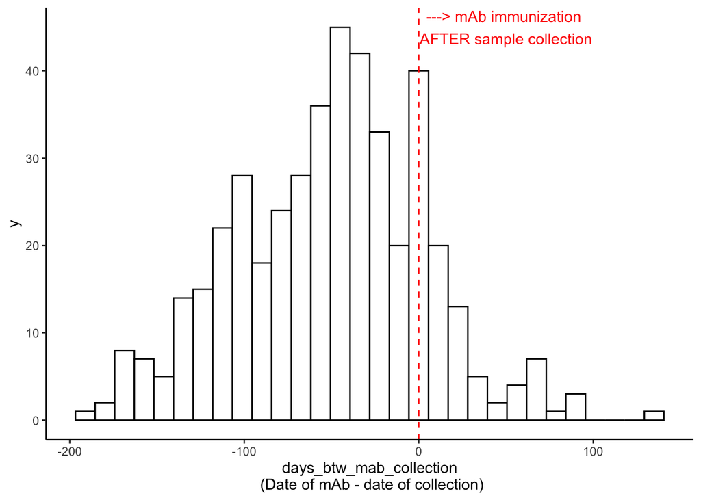

### Those who received mAb within 7 days before sample collection OR received on/after date of collection:

#### (TBC) how do we define exposure? those who are immunized with mAb before sample collection date or those who are immunized >7 days before sample collection date?

| StudyID | days_btw_mab_collection | mab_date | collection_date |
| --- | --- | --- | --- |
| 130735446 | -7 | 2023-11-27 | 2023-12-04 |
| 130719513 | -6 | 2023-10-27 | 2023-11-02 |
| 130713961 | -5 | 2023-12-25 | 2023-12-30 |
| 130750053 | -5 | 2024-01-20 | 2024-01-25 |
| 130754819 | -5 | 2023-12-15 | 2023-12-20 |
| 130755354 | -5 | 2024-01-12 | 2024-01-17 |
| 130765300 | -5 | 2024-01-23 | 2024-01-28 |
| 130783493 | -5 | 2024-02-05 | 2024-02-10 |
| 130755900 | -4 | 2023-12-13 | 2023-12-17 |
| 130765450 | -4 | 2024-01-12 | 2024-01-16 |

[output cut: 88 more lines]

### Table 26. Nirsevimab status

#### Generated new categorical variables rsv_mab_detailed, to have values of

- 50mg before collection (days_btw_mab_collection < 0)
- 100mg before collection (days_btw_mab_collection < 0)
- 50mg after collection (days_btw_mab_collection >= 0)
- 100mg after collection (days_btw_mab_collection >= 0)
- no mAb recorded but with last hepB vax recorded
- no mAb recorded and no last hepB vax recorded

| rsv_mab_detailed | n_records | perc |
| --- | --- | --- |
| 100mg after collection | 34 | 0.9 |
| 100mg before collection | 103 | 2.7 |
| 50mg after collection | 44 | 1.2 |
| 50mg before collection | 263 | 7 |
| no mAb recorded and no last hepB vax recorded | 827 | 21.9 |
| no mAb recorded but with last hepB vax recorded | 2509 | 66.4 |

#### Generated new binary variable rsv_mab from rsv_mab_detailed, to indicate if the record took mAb before collection (TBC), which is to be used as exposure in the analysis:

- 50mg before collection —> 1
- 100mg before collection —> 1
- 50mg after collection —> 0
- 100mg after collection —> 0
- no mAb recorded but with last hepB vax recorded —> 0
- no mAb recorded and no last hepB vax recorded —> 0

| rsv_mab | n_records | perc |
| --- | --- | --- |
| 0 | 3414 | 90.3 |
| 1 | 366 | 9.7 |

### Figure 9. Age at mAb

Generate new variable age_at_mab_in_days (calculated as mAb date in nir tab - DOB ) The figure below only includes records with rsv_mab == 1:

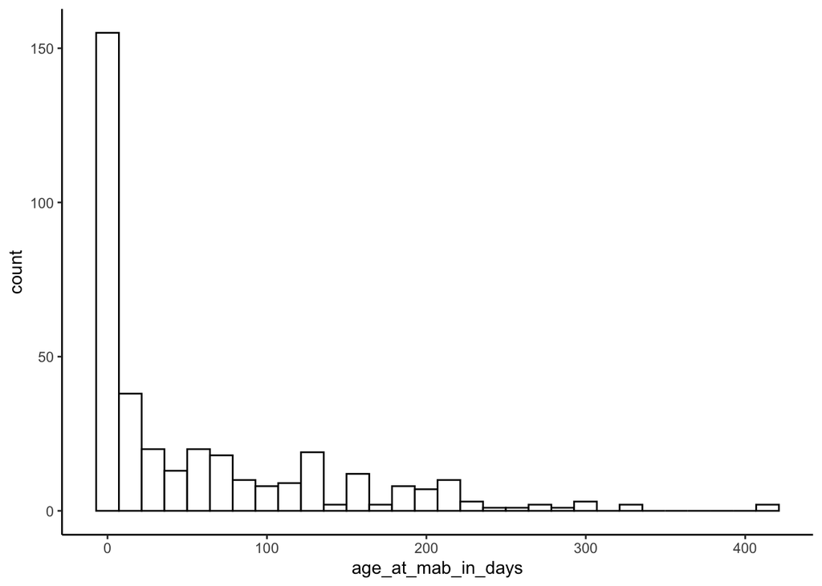

### Read in oxygen volume tab and merge with main tab

### Figure 10. Maximum oxygen flow rate

#### Generate new variable max_oxygen_flowrate (unit: L/min), which threshold to use to indicate severe outcome? (after discussing, 1.5L/min can be used as a threshold to indicate severe disease.)

- Also need to note that, there is no date in the oxygen tab, so for those patients with multiple visits, we cannot sure which record should be linked with the oxygen order.

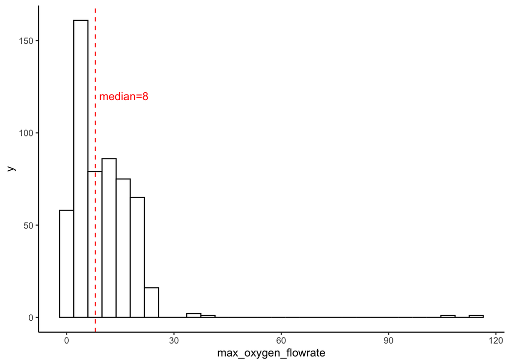

  #### Also, from “Order Questions” variable in the oxygen tab, extract whether there was CPAP (continuous positive airway pressure), BiPAP (Bilevel positive airway pressure), HFNC (high-flow nasal cannula)… ordered for each records, if there was, this is also an indication of severe disease.

#### Then, patients with max_oxygen_flowrate > 1.5L/min and patients who ordered high flow oxygen (based on order questions) were deemed “used high flow oxygen”, generate a new variable called highflow_oxygen.

| highflow_oxygen | n |
| --- | --- |
| 0 | 101 |
| 1 | 508 |
| NA | 3171 |

### For each testing record, generate unique testID

#### If a patient was tested multiple times, the testID will has values of StudyID_nthTest (e.g. 99999999_1, 9999999_2..), the suffix indicates the nth test of the patient, ordered by date of sample collection.

Also generated n_tests for each StudyID, to indicate the number of tests this individual took, and generated new variable nth_test to indicate this is the nth test of the same individual patient.

### Table 26. Time since earliest collection for each patient

#### if an individual has multiple tests, for each test, generate new variables:

- days_since_earliest_collection: the time elapse since the earliest test (in days, if this is the first test of a patient, take 0)
- days_since_last_collection: time elapse since the most recent test (in days, if this is the first test of a patient, take 0)
- days_to_next_collection: time to next collection (in days, if this is the last test of a patient, take 0).

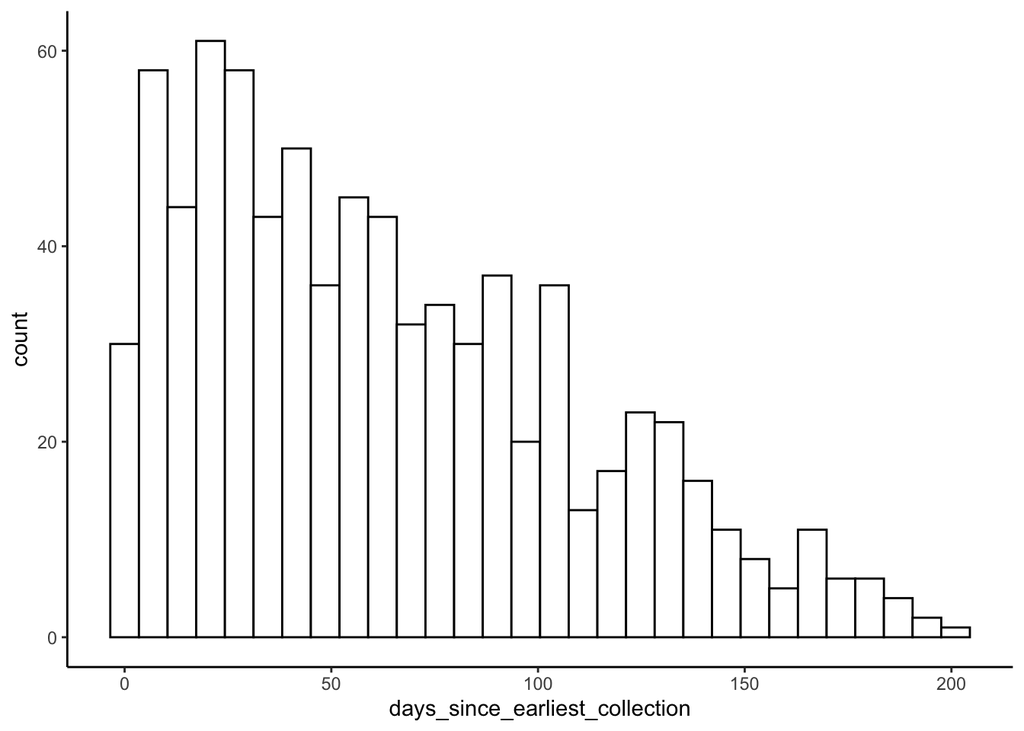

### Table 27. There are several individuals with more than one testing results on the same day. (TBC)

| StudyID | collection_date | Collection Department | positive_viruses | rsv_mab | encounter_type | Admit Date |
| --- | --- | --- | --- | --- | --- | --- |
| 130582917 | 2024-03-18 | BH EMERGENCY DEPARTMENT | NA | 0 | inpatient | 2024-03-18T00:00:00Z |
| 130582917 | 2024-03-18 | BH FAIRFIELD URGENT CARE | NA | 0 | outpatient | 2024-03-18T00:00:00Z |
| 130618601 | 2023-10-23 | LMH EMERGENCY DEPARTMENT | NA | 0 | inpatient | 2023-10-23T00:00:00Z |
| 130618601 | 2023-10-23 | YNH WP 7 PEDIATRIC INTENSIVE CARE | parainfluenza | 0 | inpatient | 2023-10-23T00:00:00Z |
| 130696938 | 2023-10-29 | BH EMERGENCY DEPARTMENT | rsv | 0 | outpatient | 2023-10-29T00:00:00Z |
| 130696938 | 2023-12-21 | YNH EMERGENCY PEDIATRIC | NA | 0 | outpatient | 2023-12-21T00:00:00Z |
| 130696938 | 2023-12-21 | BH FAIRFIELD URGENT CARE | NA | 0 | outpatient | 2023-12-21T00:00:00Z |
| 130701204 | 2024-01-20 | BH FAIRFIELD URGENT CARE | rsv | 0 | outpatient | 2024-01-20T00:00:00Z |
| 130701204 | 2024-03-29 | BH EMERGENCY DEPARTMENT | NA | 0 | outpatient | 2024-03-29T00:00:00Z |
| 130701204 | 2024-03-29 | BH FAIRFIELD URGENT CARE | NA | 0 | outpatient | 2024-03-29T00:00:00Z |

[output cut: 12 more lines]

### Save the cleaned dataset to be used for analyses.

```r
save_recoded_dataset <- FALSE


if(save_recoded_dataset){
  write.csv(df, "../../data/clean_data/df.mab.csv", row.names = F)
}

# colnames <- as.data.frame(colnames(df))
# write.csv(colnames, "../../data/clean_data/dictionary.csv", row.names = F)
```

### Mark testing records as cases and controls

(reference: https://pubmed.ncbi.nlm.nih.gov/36454733/)

#### Test-positive cases:

- A case of test-positive is defined as a positive RSV test.

#### Test-negative controls:

- Define test-negative control as a negative RSV test
  - collected at any time if this patient was tested only once, **OR**
  - collected > 7 days prior this patient’s next test **AND** collected > 7 days after this patient’s last test (if the patient was tested multiple times)

#### Other notes:

- An individual patient is allowed to contribute as both case and control, as the analysis is to be conducted at test-level, instead of patient-level.
- Each patient can contribute to up to three negative tests (controls) (TBC).
- If a person had more than one negative test within 7-day period, one random test was selected during the period as a control.

```r
##########################
# mark test-positive cases
##########################

df <- df %>% mutate(case_control = ifelse(positive_rsv == 1, "case", NA))

#############################
# mark test-negative controls
#############################

# generate a binary indicator to mark if this patient's next test is RSV positive (didn't use this)
df <- df %>%
  group_by(StudyID) %>%
  mutate(next_test_rsv_positive = lead(positive_rsv)) %>%
  # NA if a person was tested once or this is a last test of an individual
  as.data.frame()


df <- df %>%
  group_by(StudyID) %>%
  mutate(case_control = case_when(
  # 1. the patient was only tested once and was rsv negative
    (positive_rsv == 0 & n_tests == 1) |
  # 2. the patient was tested multiple times:
    # 2.1 if this is not the first or last test of the patient
    # this negative test should be >7 days prior next test AND >7 days after previous test
    (positive_rsv == 0 & n_tests > 1 & days_to_next_collection > 7 & days_since_last_collection > 7) |
    # 2.2 if this is the first test of the patient
    # this negative test should be > 7 days prior next test
    (positive_rsv == 0 & n_tests > 1 & nth_test == 1 & days_to_next_collection > 7) |
    # 2.3 if this is the last test of the patient
    # this negative test should be > 7 days after previous test
    (positive_rsv == 0 & n_tests > 1 & nth_test == n_tests & days_since_last_collection > 7) ~ "control",
    TRUE ~ case_control
  )) %>% as.data.frame()


# If a person had more than one negative test within 7-day period, one random test was selected during the period as a control
set.seed(123)
temp <- df %>%
  group_by(StudyID) %>%
  filter(
    (  ((days_to_next_collection <= 7 | days_since_last_collection <= 7) & nth_test != 1 & n_tests != nth_test) | # tests in the middle
       (nth_test == 1 & days_to_next_collection <= 7) | # first test
       (nth_test == n_tests & days_since_last_collection <= 7) # last test
    ) &  positive_rsv == 0)  %>%
  mutate(n_controls_to_sample_from = n()) %>%
  dplyr::select(StudyID, n_controls_to_sample_from) %>% unique()


df <- df %>% left_join(temp, by = "StudyID")

# random select one control
randomly.selected.controls.ids <- (df %>%
  filter(n_controls_to_sample_from > 1 & is.na(case_control)) %>%
  group_by(StudyID) %>%
  sample_n(1) %>%
  mutate(control_randomly_selected = 1))$testID

# mark these controls
df <- df %>%
  mutate(randomly_selected_control = ifelse(testID %in% randomly.selected.controls.ids, 1, 0)) %>%
  mutate(case_control = ifelse(randomly_selected_control == 1, "control", case_control))

# # individual patients contribute more than three controls (n = 17)
# df %>%
#   group_by(StudyID) %>%
#   count(case_control) %>%
#   filter(n>1) %>%
#   arrange(desc(n), StudyID) %>%
#   filter(case_control == "control") %>%
#   filter(n > 3)
```

### Table 28 Take a look at number of cases and controls.

| case_control | n | perc |
| --- | --- | --- |
| case | 846 | 22.4 |
| control | 2850 | 75.6 |
| NA | 76 | 2 |

### Table 29. There are patients who contributed 2 cases.

#### (TBC) Should we include all test-positive records as cases? Or if the two test-positive results for the same individual happened within 7(?) days, we only keep one case for this individual?

| StudyID | collection_date | tested_viruses | positive_viruses | case_control |
| --- | --- | --- | --- | --- |
| 130573264 | 2023-11-16 | flu rsv | rsv | case |
| 130573264 | 2023-12-04 | flu rsv | rsv | case |
| 130573264 | 2024-03-02 | flu rsv | NA | control |
| 130577842 | 2023-11-28 | flu rsv | rsv | case |
| 130577842 | 2023-12-18 | flu rsv | rsv | case |
| 130595932 | 2023-12-12 | flu rsv | rsv | case |
| 130595932 | 2023-12-19 | flu rsv | rsv | case |
| 130595932 | 2024-01-15 | flu rsv | NA | control |
| 130598975 | 2023-12-11 | flu rsv | rsv | case |
| 130598975 | 2023-12-23 | flu rsv | rsv | case |

[output cut: 62 more lines]

### Table 30. briefly look at risk factors by mAb status

|  | 0 (N=3408) | 1 (N=364) | P-value |
| --- | --- | --- | --- |
| factor(Sex) |  |  |  |
| Female | 1468 (43.1%) | 152 (41.8%) | 0.66 |
| Male | 1937 (56.8%) | 212 (58.2%) |  |
| Missing | 3 (0.1%) | 0 (0%) |  |
| age_at_test_in_months |  |  |  |
| Mean (SD) | 7.99 (4.29) | 4.13 (3.10) | <0.001 |
| Median [Min, Max] | 8.10 [0, 19.0] | 3.40 [0.100, 15.8] |  |
| factor(encounter_type) |  |  |  |
| inpatient | 544 (16.0%) | 85 (23.4%) | <0.001 |
| inpatient_unrelated | 45 (1.3%) | 11 (3.0%) |  |
| outpatient | 2819 (82.7%) | 268 (73.6%) |  |
| factor(insurance_type) |  |  |  |
| private | 1133 (33.2%) | 93 (25.5%) | 0.00229 |
| public | 2250 (66.0%) | 271 (74.5%) |  |
| uninsured | 25 (0.7%) | 0 (0%) |  |
| factor(risk_factor_gestage) |  |  |  |
| early term | 823 (24.1%) | 106 (29.1%) | <0.001 |
| full term | 1271 (37.3%) | 118 (32.4%) |  |
| late term | 164 (4.8%) | 11 (3.0%) |  |
| post term | 2 (0.1%) | 0 (0%) |  |
| preterm | 346 (10.2%) | 101 (27.7%) |  |
| Missing | 802 (23.5%) | 28 (7.7%) |  |
| factor(risk_factor_cvd) |  |  |  |
| 1 | 144 (4.2%) | 37 (10.2%) | <0.001 |
| Missing | 3264 (95.8%) | 327 (89.8%) |  |
| factor(risk_factor_gi) |  |  |  |
| 1 | 28 (0.8%) | 10 (2.7%) | 0.0035 |
| Missing | 3380 (99.2%) | 354 (97.3%) |  |
| factor(risk_factor_pulmonary) |  |  |  |
| 1 | 144 (4.2%) | 21 (5.8%) | <0.001 |
| Missing | 3264 (95.8%) | 343 (94.2%) |  |
| factor(risk_factor_asthma) |  |  |  |
| 1 | 155 (4.5%) | 9 (2.5%) | <0.001 |
| Missing | 3253 (95.5%) | 355 (97.5%) |  |
| factor(risk_factor_anemia) |  |  |  |
| 1 | 91 (2.7%) | 12 (3.3%) | <0.001 |
| Missing | 3317 (97.3%) | 352 (96.7%) |  |